# PS811 Portfolio

Sam Schutt

### Research Interests

I am interested in policy made by unelected institutions within democracies, especially how activists and social movements influence bureaucratic policymaking in the United States.

Methodologically, this means that I am trying to figure out how to measure policy change and identify its causes.

### Questions I hope to answer

How do we distinguish grassroots and astroturf activism? Does either affect policy? When and why do Members of Congress lobby federal agencies? How do we measure policy change and attribute influence?

### Methods

Text analysis (reuse, topic models and other Bayesian classifiers, content analysis), various regression models including duration models, field experiments, and process tracing.

### Relevent data

- Adam Bonica’s DIME database of campaign contributions ( [data](https://data.stanford.edu/dime_) )
- Jennifer Selin’s data on agency inpendence ( [article](https://onlinelibrary.wiley.com/doi/abs/10.1111/ajps.12161) )
- Charles Stewart’s congressional committee membership data ( [data](http://web.mit.edu/17.251/www/data_page.html) )
- U.S. Census
- Mark Richards and Bert Kritzer’s data on supreme court decisionmaking ( [article](https://www.cambridge.org/core/journals/american-political-science-review/article/jurisprudential-regimes-in-supreme-court-decision-making/E6367C1260F08FBD798DE09992E56534) )

### Something cool

Using DIME ideology scores (based on campaign donations):

```r
## load data from a web address
load(url("https://github.com/judgelord/state-level-DIME/raw/master/data/BonicaStateLevel.Rdata"))

d %<>%
  ## naming things!
  rename(Governor = gov_cf) %>%
  rename(Lower = l_cf_median) %>%
  rename(Upper = u_cf_median) %>%
  mutate(party = ifelse(dist_1_x_zero == 0 & Governor < 0, "All Liberal", "Mixed")) %>%
  mutate(party = ifelse(dist_1_x_zero == 0 & Governor > 0, "All Conservative", party)) %>%
  mutate(party = ifelse(is.na(dist_1_x_zero) & Governor > 0, "All Conservative", party)) %>%
  ## identify min and max DIME scores for each state (each row is a state)
  mutate(min = pmin(Governor, Lower, Upper, na.rm = T),
         max = pmax(Governor, Lower, Upper, na.rm = T) )
```

And a function for plotting them:

```r
## Define a function for plotting state-level DIME data with ggplot
DIMEplot <- function(d){
  d %>%
    # define y as state for all layers
  ggplot(aes(y = reorder(state, distance_1_gov_leg_med))) +
    # x = lines for the distance between max and min actors
  geom_segment(aes(x = min,
                   xend = max,
                   yend = reorder(state, distance_1_gov_leg_med)),
               color = "grey",
               size = 2.1,
               lineend = "round",
               alpha = .3) +
    # x = points for each actor
  geom_point(aes(x = Governor, color = Governor), shape = "G") +
  geom_point(aes(x = Lower, color = Lower), shape = "L") +
  geom_point(aes(x = Upper, color = Upper), shape = "U") +
    # labels
  labs(y = "States by Preference Divergence",
       x = "Mean Ideology Score",
       title = paste("Preference Divergence of Political Principals,", unique(d$year) ), color = "") +
    # scales
  scale_x_continuous(breaks = c(-1, 0, 1)) +
  scale_colour_gradient2(low = "blue", mid = "black", high = "red") +
    # facet by liberal, conservative, or mixed
  facet_grid(party ~ ., scales = "free_y", space = "free_y") +
    # adjust text size and drop legend
  theme(axis.text.y = element_text(size = 5),
        title = element_text(size = 7),
        legend.position = "none")
}
```

We can compare alignment among governors (G) and upper (U) and lower (L) chambers of state legislatures between 2004 and 2008:

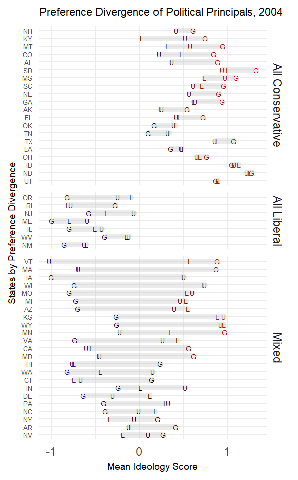

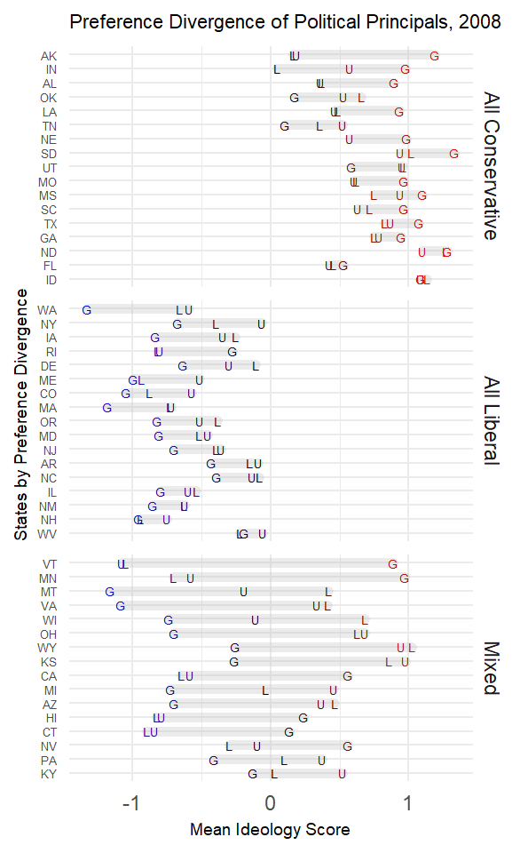

```r
d %>%
  filter(year == 2004) %>%
  DIMEplot()

d %>%
  filter(year == 2008) %>%
  DIMEplot()
```